# LandR *Biomass_borealDataPrep* Manual

Last updated: 2026-10-26

#### Authors:

Yong Luo Yong.Luo@gov.bc.ca [aut], Eliot J B McIntire eliot.mcintire@nrcan-rncan.gc.ca [aut, cre], Ceres Barros ceres.barros@ubc.ca [aut], Alex M. Chubaty achubaty@for-cast.ca [aut]

**This documentation is a work in progress. Potential discrepancies and omissions may exist for the time being. If you find any, contact us using the “Get help” link above.**

## Module Overview

### Quick links

- General functioning
- List of input objects
- List of parameters
- List of outputs
- Simulation flow and module events

### Summary

LandR *Biomass_borealDataPrep* (hereafter *Biomass_borealDataPrep*), prepares all necessary inputs for *Biomass_core* based on data available for forests across Canada forests, but focused on Western Canada boreal forest systems. Nevertheless, it provides a good foundation to develop other modules aimed at different geographical contexts. By keeping data preparation and parameter estimation outside of *Biomass_core*, we promote the modularity of the LandR-based model systems and facilitate interoperability with other parameter estimation procedures.

Specifically, it prepares and adjusts invariant and spatially-varying species trait values, as well as ecolocation-specific parameters, probabilities of germination and initial conditions necessary to run *Biomass_core*. For this, *Biomass_borealDataPrep* requires internet access to retrieve default data[^1].

We advise future users to run *Biomass_borealDataPrep* with defaults and inspect the resulting input objects are like before supplying alternative data (or data URLs).

### Links to other modules

*Biomass_borealDataPrep* is intended to be used with [*Biomass_core*](https://github.com/PredictiveEcology/Biomass_core), but can be linked with other data modules that prepare inputs. See [here](https://rpubs.com/PredictiveEcology/LandR_Module_Ecosystem) for all available modules in the LandR ecosystem and select *Biomass_borealDataPrep* from the drop-down menu to see potential linkages.

- [*Biomass_core*](https://github.com/PredictiveEcology/Biomass_core): core forest dynamics simulation module. Used downstream from *Biomass_borealDataPrep*;
- [*Biomass_speciesData*](https://github.com/PredictiveEcology/Biomass_speciesData): grabs and merges several sources of species cover data, making species percent cover (% cover) layers used by other LandR Biomass modules. Default source data spans the entire Canadian territory. Used upstream from *Biomass_borealDataPrep*;
- [*Biomass_speciesParameters*](https://github.com/PredictiveEcology/Biomass_speciesParameters): calibrates four-species level traits using permanent sample plot data (i.e., repeated tree biomass measurements) across Western Canada. Used downstream from *Biomass_borealDataPrep*.

## Module manual

### General functioning

*Biomass_borealDataPrep* prepares all inputs necessary to run a realistic simulation of forest dynamics in Western Canadian boreal forests using *Biomass_core*. Part of this process involves cleaning up the input data and imputing missing data in some cases, which are discussed in detail in Data acquisition and treatment.

After cleaning and formatting the raw input data, the module:

1. **calculates species biomass per pixel** by multiplying the observed species % cover by the observed stand biomass and an adjustment factor, which can be statistically calibrated for the study area. Given that this adjusts the species biomass, this calibration step contributes to the calibration of `maxB` and `maxANPP` trait values, whose estimation is also based on species biomass (see Initial species age and biomass per pixel and Adjustment of species biomass);
2. prepares **invariant species traits** – these are spatio-temporally constant species traits that influence population dynamics (e.g., growth, mortality, dispersal) and responses to fire (see Invariant species traits);
3. defines **ecolocations** – groupings of pixels with similar biophysical conditions. By default, ecolocations are defined as the spatial combination of ecodistricts of the National Ecological Framework for Canada, and the Land Cover of Canada 2010 map (see Defining simulation pixels and ecolocations). **Note that ecolocation is termed `ecoregionGroup` across LandR modules**.
4. prepares **ecolocation-specific parameters** and **probabilities of germination** – only one ecolocation-specific parameter is used, the minimum relative biomass thresholds, which defines the level of shade in a pixel. Together the level of shade and the probabilities of germination influence germination success in any given pixel;
5. estimates **spatio-temporally varying species traits** – species traits that can vary by ecolocation and in time. These are maximum biomass (`maxB`), maximum above-ground net primary productivity (`maxANPP`; see Maximum biomass and maximum aboveground net primary productivity) and species establishment probability (SEP, called `establishprob` in the module traits table; see Species establishment probability). **By default, *Biomass_borealDataPrep* estimates temporally constant values of `maxB`, `maxANPP` and SEP**;
6. creates **initial landscape conditions** – *Biomass_borealDataPrep* performs data-based landscape initialisation, by creating the species cohort table (`cohortData`) and corresponding map (`pixelGroupMap`; both used to initialise and track cohorts across the landscape) based on observed stand age and species biomass.

As *Biomass_core* only simulates tree species dynamics, *Biomass_borealDataPrep* prepares all inputs and estimates parameters in pixels within forested land-cover classes (see Defining simulation pixels and ecolocations).

If a `studyArea_biomassParam` is supplied, the module uses it for parameter estimation to account for larger spatial variability.

In the next sections, we describe in greater detail the various data processing and parameter estimation steps carried out by *Biomass_borealDataPrep*.

### Data acquisition and treatment

The only two objects that the user must supply are spatial polygons that define the study area used to derive parameters (`studyArea_biomassParam`), and the study area where the simulation will happen (`studyArea`). The two objects can be identical if the user chooses to parametrise and run the simulations in the same area. If not identical, `studyArea` must be fully within `studyArea_biomassParam`. If `studyArea_biomassParam` and `studyArea` are in Canada, the module can automatically estimate and prepare all input parameters and objects for *Biomass_core*. Best attempts are made to use FAIR data (*sensu* Wilkinson *et al.* 2016) at the national-scale; however, the default SCANFI 2020 datasets are unpublished, and not yet publicly available. The previous default using the Canadian National Forest Inventory (NFI) forest attributes kNN dataset [`KNN`; Beaudoin *et al.* (2014), Beaudoin *et al.* (2017)] for `dataYear = 2001` or `2011` is still available.

If no other inputs are supplied, *Biomass_borealDataPrep* will create raster layer versions `studyArea_biomassParam` and `studyArea` (`rasterToMatch_biomassParam` and `rasterToMatch`.

#### Defining simulation pixels and ecolocations

*Biomass_borealDataPrep* uses land-cover data to define and assign parameter values to the pixels where forest dynamics will be simulated (forested pixels). By default it uses land-cover classes derived from the Spatialized Canadian National Forest Inventory [`SCANFI`; Guindon *et al.* (2023), Guindon *et al.* (2024)], a raster-based database that distinguishes several forest and non-forest land-cover types. The original SCANFI LCC codes are substituted with their corresponding values according to the National Terrestrial Ecosystem Monitoring System for Canada Land Cover [`NTEMS`; Hermosilla *et al.* (2022)] classification. Pixels with classes 81, 210, 220, 230, and 240 are included as forested pixels (see parameter `forestedLCCClasses`).

When the land-cover raster (`rstLCC`) includes transient cover types (e.g., recently disturbed) the user may pass a vector of transient class IDs (via the parameter `LCCClassesToReplaceNN`) that will be reclassified into a “stable” forested class (defined via the parameter `forestedLCCClasses`). The reclassification is done by searching the focal neighbourhood for a replacement forested cover class (up to a radius of 1250m from the focal cell). If no forested class is found within this perimeter, the pixel is not used to simulate forest dynamics. Reclassified pixels are omitted from the fitting of statistical models used for parameter estimation, but are assigned predicted values from these models.

Sub-regional spatial variation in `maxBiomass`, `maxANPP`, and SEP species traits is accounted for by ecolocation. Ecolocations are used as proxies for biophysical variation across the landscape when estimating model parameters that vary spatially. By default, they are defined as the combination of “ecodistricts” from the [National Ecological Framework for Canada](https://open.canada.ca/data/en/dataset/3ef8e8a9-8d05-4fea-a8bf-7f5023d2b6e1) (a broad-scale polygon layer that captures sub-regional variation) (`ecoregionLayer`) and the above land cover (`rstLCC`), but the user can change this by supplying different ecozonation or land-cover layers.

#### Species cover

Species cover (% cover) raster layers (`speciesLayers`) can be automatically obtained and pre-processed by *Biomass_borealDataPrep*. The module ensures that:

1. all data have the same geospatial properties (extent, resolution);
2. all layers these are correctly re-projected to `studyArea_biomassParam` and `rasterToMatch_biomassParam`;
3. species with no cover values above 10% are excluded.

By default it uses species % cover rasters derived from the Spatialized Canadian National Forest Inventory [`SCANFI`; Guindon *et al.* (2023), Guindon *et al.* (2024)] – hereafter ‘SCANFI species data’.

#### Initial species age and biomass per pixel

Stand age and aboveground stand biomass (hereafter ‘stand biomass’) are used to derive parameters and define initial species age and biomass across the landscape. These are also derived from SCANFI Guindon *et al.* (2024) by default.

*Biomass_borealDataPrep* downloads these data and performs a number of data harmonization operations to deal with data inconsistencies. It first searches for mismatches between stand age (`standAge`), stand biomass (`standB`) and total stand cover (`standCover`), assuming that cover is the most accurate of the three, and biomass the least, and in the following order:

1. Pixels with `standCover < 5%` are removed;
2. Pixels with `standAge == 0`, are assigned `standB == 0`;
3. Pixels with `standB == 0`, are assigned `standAge == 0`.

Then, species is assigned one cohort per pixel according to the corrected stand age, stand biomass and % cover values. Cohort age is assumed to be the same as stand age and biomass is the product of stand biomass and species % cover. Before doing so, stand cover is rescaled to vary between 0 and 100%.

A next set of data inconsistencies in cohort age (`age`), biomass (`B`) and cover (`cover`) is looked for and solved in the following order:

4. if `cover > 0` and `age == 0`, `B` is set to 0 (and stand biomass recalculated);
5. if `cover == 0` and `age > 0`, or if `age == NA`, `age` is empirically estimated using the remainder of the data to fit the model supplied by `P(sim)$imputeBadAgeModel`, which defaults to:

```
## [[1]]
## lme4::lmer(log(age) ~ log(totalBiomass) * cover * speciesCode +
##     (log(totalBiomass) | initialEcoregionCode))
```

Cohort biomass is then adjusted to reflect the different cover to biomass relationship of conifer and broadleaf species (see Adjustment of initial species biomass).

#### Replacing initial biomass and age within known fire perimeters

*Biomass_borealDataPrep* can use fire perimeters to correct stand ages. To do so, it downloads the latest fire perimeter data from the [Canadian Wildfire Data Base](https://cwfis.cfs.nrcan.gc.ca/datamart) and changes pixel age inside fire perimeters to match the time since last fire, using fire years up to the first year of the simulation.

Taking two independent datasets for stand age (fire perimeters) and stand biomass (derived from MODIS satellite imagery) can cause discrepancies (e.g., stand age = 5 and aboveground biomass = 10000 $m^2 / ha$). This may be due to errors coming from: a) a stand replacing disturbance that reset age to zero a few years before, but the biomass layer was no zeroed; b) the disturbance was not stand-replacing (leaving biomass), but age was still zeroed. This means that either, aboveground biomass is wrong or age is.

Options to address this include 1) get better data for these two variables that do not contradict one another (not currently available to us) or 2) estimate one or the other. There is no obvious way to decide which one is incorrect, unless there is an independent data source.

This assumes that 1) recorded fires were stand-replacing, and so time since fire is the new stand age and 2) that the first year of the simulation is later than the first fire year in the fire perimeter data. The biomass spin-up with *Biomass_core* is only run in pixels were stand ages were corrected, for as long as the new stand age (i.e., the time since last fire). All specie start with age = 0 and biomass = 0, and grow until time since last fire is achieved. The resulting species biomass is used as the initial biomass values for each species cohort in the actual simulation.

If the user does not want to perform this imputation, this step can be bypassed by setting the parameter `P(sim)$overrideBiomassInFires` to `FALSE` or `P(sim)$fireURL` to `NULL` or `NA`.

Whenever `P(sim)$overrideAgeInFires` is `TRUE`, ages up to `dataYear - earliestFireYear`, the ages fire records can date, are kept exact rather than rounded to `P(sim)$pixelGroupAgeClass`, also when the biomass spin-up is skipped. Rounding them would put stands younger than half an age class at age 0, and *Biomass_core* adds no year to an age-0 cohort: it stays at 0 until the first age reclassification, `successionTimestep` years in, sets it to `successionTimestep + 1`.

Also pixels that suffered *any kind* of data imputation (e.g., the age corrections detailed in the previous section) can be excluded from the simulation by setting `P(sim)$rmImputedPix == TRUE`.

#### Invariant species traits

Most invariant species traits are obtained from available species trait tables used in LANDIS-II applications in Canada’s boreal forests (available in [Dominic Cyr’s GitHub repository](https://github.com/dcyr/LANDIS-II_IA_generalUseFiles)). Some are then adapted with minor adjustments to match Western Canadian boreal forests using published literature. Others (key growth and mortality traits) can be calibrated by *Biomass_speciesParameters* (see Calibrating species growth/mortality traits using *Biomass_speciesParameters*).

The LANDIS-II species trait table contains species trait values for each Canadian Ecozone (NRCan 2013), which are by default filtered to the Boreal Shield West (BSW), Boreal Plains (BP) and Montane Cordillera Canadian Ecozones (via `P(sim)$speciesTableAreas`). Most trait values do not vary across these ecozones for a given species, but when they do the minimum value is used.

The function `LandR::speciesTableUpdate` is used by default to do further adjustments to trait values in this table (if this is not intended, a custom function call or `NULL` can be passed to `P(sim)$speciesUpdateFunction`):

- Longevity values are adjusted to match the values from Burton & Cumming (1995), which match BSP, BP and MC ecozones. These adjustments result in higher longevity for most species;
- Shade tolerance values are lowered for *Abies balsamifera*, *Abies lasiocarpa*, *Picea engelmanii*, *Picea glauca*, *Picea mariana*, *Tsuga heterophylla* and *Tsuga mertensiana* to better **relative** shade tolerance levels in Western Canada. Because these are relative shade tolerances, the user should **always** check these values with respect to their own study areas and species pool.

The user can also pass more than one function call to `P(sim)$speciesUpdateFunction` if they want to make other adjustments in addition to those listed above (see `?LandR::updateSpeciesTable`).

#### Probabilities of germination

By default, *Biomass_borealDataPrep* uses the same probabilities of germination (called `sufficientLight` in the module) as *Biomass_core*. These are obtained from publicly available [LANDIS-II table](https://raw.githubusercontent.com/LANDIS-II-Foundation/Extensions-Succession/master/biomass-succession-archive/trunk/tests/v6.0-2.0/biomass-succession_test.txt).

### Parameter estimation/calibration

#### Adjustment of initial species biomass

*Biomass_borealDataPrep* estimates initial values of species aboveground biomass (`B`) based on stand biomass (`standB`) and individual species % cover. Initial `B` is estimated for each species in each pixel by multiplying `standB` by species % cover. Because the default cover layers are satellite-derived, the relationship between relative cover and relative biomass of broadleaf and conifer species needs to be adjusted to reflect their different canopy architectures (using `P(sim)$deciduousCoverWeight`).

`P(sim)$deciduousCoverWeight` is how much biomass a unit of deciduous cover carries relative to a unit of conifer cover. Broadleaf crowns are wider per unit of wood, so it is expected below 1.

By default (`P(sim)$fitDeciduousCoverWeight == TRUE`) it is **estimated from `studyArea_biomassParam`** rather than taken from the parameter, because it is not a universal constant: on 100 km of Alberta boreal mixedwood the fit gives 0.90, and per ecoregion inside that one window it ranges 0.80 to 1.11.

`partitionBiomass()` splits a pixel’s `standB` among its cohorts and so says nothing about the total it divides; what identifies the weight is a statement about the total,

$$standB_p = k_p \times (C_p + w \times D_p)$$

where $C_p$ and $D_p$ are the pixel’s total conifer and deciduous cover. What $k$ is decides what is estimated. Held constant within an ecoregion, $w$ absorbs site quality – in the boreal, broadleaf grows on richer, better-drained ground than black spruce, so the estimate comes back **above** 1 and has credited the site to the species. Made a function of the pixel’s own canopy height and closure (`sim$rstCanopyHeight`, `sim$rstCanopyClosure`, SCANFI’s own layers), it compares composition between stands carrying the *same* amount of structure, which is the canopy-architecture difference the parameter is for. That is what the module fits, by profiling $w$ with $k$ concentrated out; the design matrix does not depend on $w$, so the whole search costs a few seconds.

Where the study area cannot identify it – too little deciduous cover, no canopy height and closure layers (only SCANFI publishes them), or an estimate sitting on the search bound – the module says so and keeps `P(sim)$deciduousCoverWeight`. Set `P(sim)$fitDeciduousCoverWeight == FALSE` to always use the parameter.

#### Maximum biomass and maximum aboveground net primary productivity

*Biomass_borealDataPrep* statistically estimates maximum biomass (`maxB`) and maximum aboveground net primary productivity (`maxANPP`) using the processed species ages and biomass.

`maxB` is estimated by modelling the response of species biomass (`B`) to species age and cover, while accounting for variation between ecolocations (`ecoregionGroup` below):

```
## [[1]]
## lme4::lmer(B ~ logAge * speciesCode + cover * speciesCode + (logAge +
##     cover | ecoregionGroup))
```

The coefficients are estimated by maximum likelihood and model fit is calculated as the proportion of explained variance explained by fixed effects only (marginal r2) and by the entire model (conditional r2) – both of which are printed as messages.

Because the model can take a while to fit, by default we sample pixels within each species and ecolocation combination (sample size defined by the `P(sim)$subsetDataBiomassModel` parameter).

If convergence issues occur and `P(sim)$fixModelBiomass == TRUE`, the module attempts to refit the model by re-sampling the data, re-fitting `lmer` with the `bobyqa` optimizer, and re-scaling the continuous predictors (by default, `cover` and `logAge`). These steps are tried additively until the convergence issue is resolved. If the module is still unable to solve the convergence issue a message is printed and the module uses the last fitted model.

Note that convergence issues are not usually problematic for the estimation of coefficient values, only for estimation of their standard errors. However, the user should always inspect the final model (especially if not converged) and make sure that the problems are not significant and that the fitted model meets residual assumptions. For this, the user should make sure model objects are exported to the `simList` using the `exportModels` parameter.

Alternative model calls/formulas can be supplied via the `P(sim)$biomassModel` parameter. Note that if supplying a model call that does not use `lme4::lmer` the refitting process is likely to fail and may have to be disabled (via the `P(sim)$fixModelBiomass` parameter).

Another consideration to add with respect to the estimation of `maxB`, is that we are choosing a linear model to relate `B ~ log(age) + cover`. This is not ideal from an ecological point of view, as biomass is unlikely to vary linearly with age or cover, and more likely to saturate beyond a certain high value of cover and follow a hump-shaped curve with age (i.e., reaching maximum values for a given age, and then starting to decrease as trees approach longevity). Also, fitting a linear model can lead to negative `B` values at young ages and low cover. However, our tests revealed that a linear mixed effects model was not producing abnormal estimates of `B` at maximum values of age and cover (hence, `maxB` estimates), while allowing to leverage on the powerful statistical machinery of `lme4`.

Finally, we highlight that modelling `log(B)` is NOT an appropriate solution, because it will wrongly assume an *exponential* relationship between `B ~ log(age) + cover`, leading to a serious overestimation of `maxB`(Fig. 1) and steep increases in species biomasses during the first years of the simulation (Fig. 2).

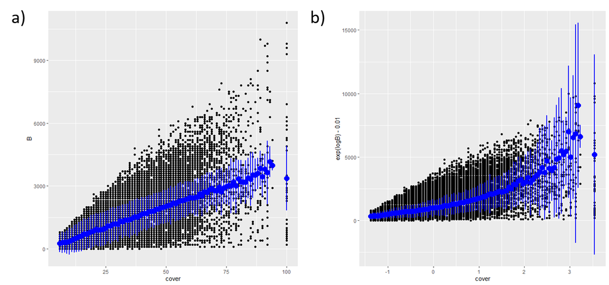

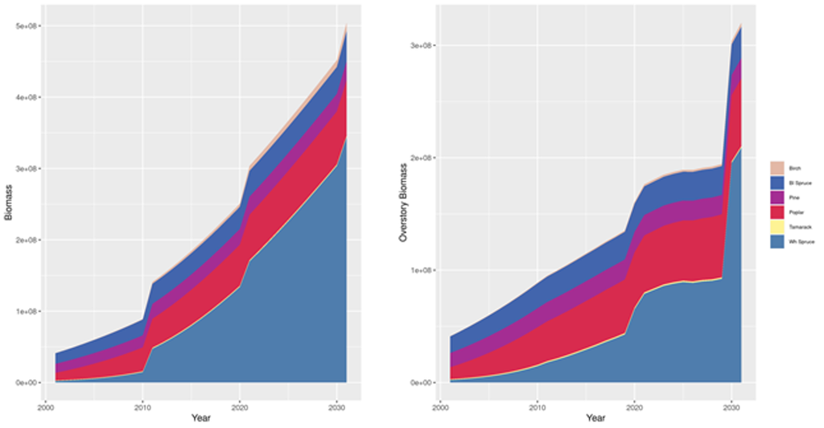

Figure 2: Thirty years of simulation with `maxB` values estimated from a `logB ~ ...` `biomassModel` (see Fig. 1). The steep increase in such little time is abnormal.

After the biomass model is fit, `maxB` is predicted by species and ecolocation combination, for maximum species cover values (100%) and maximum log-age (the log of species longevity). When using *Biomass_speciesParameters*, `maxB` is calibrated so that species can achieve the maximum observed biomass during the simulation (see Calibrating species growth/mortality traits using *Biomass_speciesParameters*).

The age covariate of this model is each cohort’s age from `standAgeMap`, unless the optional input `standAgeMapForMaxB` is supplied. The model is then fitted with that layer’s age instead, and nothing else uses it: cohort ages, `cohortData` and the strata keep `standAgeMap`. This lets the fit use the age product made with the biomass map whose values it fits (for SCANFI, its own stand age) when the cohorts start from another stand age. Cohorts with no age, or age 0, in `standAgeMapForMaxB` are left out of the fit. An `ecoregionGroup` in which no cohort has an age in `standAgeMapForMaxB` is fitted with its cohorts’ age in `standAgeMap` instead, under the same rule, because `maxB` cannot be predicted for a group the fit has no data for.

`maxANPP` is the calculated as `maxB * mANPPproportion/100`, where `mANPPproportion` defaults to 3.33, unless calibrated by *Biomass_speciesParameters* (see Calibrating species growth/mortality traits using *Biomass_speciesParameters*). The default value, 3.33, comes from an inversion of the rationale used to calculate `maxB` in Scheller & Mladenoff (2004). There, the authors estimated `maxANPP` using the model PnET-II (and then adjusted the values manually) and from these estimates calculated `maxB` by multiplying the estimated `maxANPP` by 30.

#### Species establishment probability

Species establishment probability (SEP, `establishprob` in the module) is estimated by modelling the probability of observing a given species in each ecolocation. For this, *Biomass_borealDataPrep* models the relationship between probability of occurrence of a species ($\pi$) using the following model by default:

```
## [[1]]
## glm(cbind(coverPres, coverNum - coverPres) ~ speciesCode * ecoregionGroup,
##     family = binomial)
```

whereby the probability of occurrence of a species ($\pi$) – calculated as the proportion of pixels with % cover > 0 – is modelled per species and ecolocation following a binomial distribution with a logit link function. There is no data sub-sampling done before fitting the SEP statistical model, as the model fits quickly even for very large sample sizes (e.g., > 20 million points).

This is important, since seed establishment only occurs once at every `P(sim)$successionTimestep`, and thus the probabilities of seed establishment need to be temporally integrated to reflect the probability of a seed establishing in this period of time.

Finally, since the *observed* species cover used to fit `coverModel` is a result of both seed establishment and resprouting/clonal growth, the final species establishment probabilities are calculated as a function of the temporally integrated presence probabilities and species’ probabilities of resprouting (`resproutprob`, in the `species` table) (bounded between 0 and 1):

$$\begin{equation}
SEP = integratedSEP * (1 - resproutprob)
\tag{2}
\end{equation}$$

if $SEP > 1$, then:

$$\begin{equation}
SEP = 1
\tag{3}
\end{equation}$$

if $SEP < 0$, then:

$$\begin{equation}
SEP = 0
\tag{4}
\end{equation}$$

#### Ecolocation-specific parameter – minimum relative biomass

Minimum relative biomass (`minRelativeB`) is a spatially-varying parameter used to determine the shade level in each pixel. Each shade class (X0-X5) is defined by a minimum relative biomass threshold compared to the pixel’s current relative biomass, which is calculated as the sum of pixel’s total biomass divided by the total potential maximum biomass in that pixel (the sum of all `maxB` for the pixel’s ecolocation).

Since we found no data to base the parametrisation of the shade class thresholds, default values are based on publicly available values used in LANDIS-II applications in Canada’s boreal forests (available in [Dominic Cyr’s GitHub repository](https://github.com/dcyr/LANDIS-II_IA_generalUseFiles)), and all ecolocations share the same values.

Initial runs revealed excessive recruitment of moderately shade-intolerant species even as stand biomass increased, so values for shade levels X4 and X5 are adjusted downwards (X4: 0.8 to 0.75; X5: 0.90 to 0.85) to reflect higher competition for resources (e.g. higher water limitation) in Western Canadian forests with regards to Eastern Canadian forests (Messier *et al.* 1998), which are likely driven by higher moisture limitation in the west (Hogg *et al.* 2008; Peng *et al.* 2011).

This adjustment can be bypassed by either supplying a `minRelativeB` table, or an alternative function call to `P(sim)$minRelativeBFunction` (which by default is `LandR::makeMinRelativeB`.

The minimum biomass threshold of a shade level of `X0` is `0` `standB`.

#### Calibrating species growth/mortality traits using *Biomass_speciesParameters*

If using *Biomass_borealDataPrep* and *Biomass_speciesParameters*, the later module calibrates several species traits that are first prepared by *Biomass_borealDataPrep*:

- `growthcurve`, `mortalityshape` – which initially come from publicly available LANDIS-II tables;
- `maxBiomass`, `maxANPP` – which are estimated statistically by *Biomass_borealDataPrep* (see Maximum biomass and maximum aboveground net primary productivity).

Briefly, *Biomass_speciesParameters*:

1. Uses ~41,000,000 hypothetical species’ growth curves (generated with *Biomass_core*), that cover a fully factorial combination of longevity, ratio of `maxANPP` to `maxBiomass`, `growthcurve`, `mortalityshape`;
2. Takes permanent and temporary sample plot (PSP) data in or near the study area for the target species, and finds which hypothetical species’ growth curve most closely matches the growth curve observed in the PSP data – on a species-by-species base. This gives us each species’ `growthcurve`, `mortalityshape`, and a new species trait, `mANPPproportion`, a ratio of maximum aboveground net primary productivity (`maxANPP`) to maximum biomass (`maxBiomass`, not to be confounded with `maxB`) in the study area.
3. Introduces a second new species trait, `inflationFactor`, and re-calibrates `maxB`. We recognize that `maxB`, as obtained empirically by *Biomass_borealDataPrep*, cannot be easily reached in simulations because all reasonable values of `growthcurve`, `mortalityshape` and `longevity` prevent the equation from reaching `maxB` (it acts as an asymptote that is never approached). The `inflationFactor` is calculated as the ratio of `maxBiomass` (the parameter used to generate theoretical growth curves in step 1) to the maximum biomass *actually* achieved by the theoretical growth curves (step 1). `maxB` is then recalibrated by multiplying it by `inflationFactor`. By doing this, resulting non-linear growth curves generated doing *Biomass_core* simulation will be able to achieve the the empirically estimated `maxB`.
4. Estimates species-specific `maxANPP` by multiplying the final `maxB` above by `mANPPproportion` (estimated in step 2).

In cases where there is insufficient PSP data to perform the above steps, `maxB` and `maxANPP` are left as estimated by *Biomass_borealDataPrep* (see Maximum biomass and maximum aboveground net primary productivity) and `inflationFactor` and `mANPPproportion` take default values of 1 and 3.33.

### Aggregating species

*Biomass_borealDataPrep* will use the input table `sppEquiv` and the parameter `P(sim)$sppEquivCol` to select the naming convention to use for the simulation (see full list of input objects and parameters for details). The user can use this table and parameter to define groupings that “merge” similar species that have their own invariant trait values (see Invariant species traits) (e.g. genus-level group or a functional group). To do so, the name of the species group in `sppEquivCol` column of the `sppEquiv` table must be identical for each grouped species.

| Species | SCANFI | Boreal | Modelled as |
| --- | --- | --- | --- |
| Abies balsamea | ABIE_BAL | Abie_Bal | Abies balsamea |
| Abies lasiocarpa | ABIE_LAS | Abie_Las | Abies lasiocarpa |
| Picea engelmannii | PICE_ENG | Pice_Eng | Picea engelmannii |
| Picea engelmannii x glauca | PICE_ENG_GLA | Pice_Eng_Gla | Picea engelmannii x glauca |
| Picea glauca | PICE_GLA | Pice_Gla | Picea glauca |
| Picea mariana | PICE_MAR | Pice_Mar | Picea mariana |
| Picea spp. |  | Pice_Spp | Picea spp. |
| Pinus contorta |  | Pinu_Con | Pinus contorta |
| Pinus contorta var. contorta | PINU_CON_CON | Pinu_Con | Pinus contorta var. contorta |
| Pinus contorta var. latifolia | PINU_CON_LAT | Pinu_Con | Pinus contorta var. latifolia |

When groups contain species with different (invariant) trait values, the minimum value across all species is used. As for the default species % cover layers, *Biomass_borealDataPrep* proceeds in the same way as *Biomass_speciesData* and sums cover across species of the same group per pixel.

### List of input objects

Below are is the full lists of input objects (Table 2) that *Biomass_borealDataPrep* expects.

The only inputs that **must** be provided (i.e., *Biomass_borealDataPrep* does not have a default for) are `studyArea` (the study area used to simulate forest dynamics *Biomass_core*) and `studyArea_biomassParam` (a potentially larger study area used to derive parameter values – e.g., species traits).

All other input objects and parameters have internal defaults.

Of these inputs, the following are particularly important and deserve special attention:

**Spatial layers**

**Tables**

- `speciesTable` – a table of invariant species traits that must have the following columns (even if not all are necessary to the simulation): “species”, “Area”, “longevity”, “sexualmature”, “shadetolerance”, “firetolerance”, “seeddistance_eff”, “seeddistance_max”, “resproutprob”, “resproutage_min”, “resproutage_max”, “postfireregen”, “leaflongevity”, “wooddecayrate”, “mortalityshape”, “growthcurve”, “leafLignin”, “hardsoft”. The order can vary but the column names must be identical. See Scheller & Miranda (2015) and *Biomass_core* manual for further detail about these columns.

Table 2: List of *Biomass_borealDataPrep* input objects and their description.

| objectName | objectClass | desc | sourceURL |
| --- | --- | --- | --- |
| cloudFolderID | character | The google drive location where cloudCache will store large statistical objects | NA |
| columnsForPixelGroups | character | The names of the columns in `cohortData` that define unique `pixelGroup`s. Default is `c('ecoregionGroup', 'speciesCode', 'age', 'B')`; see `?LandR::columnsForPixelGroups()`). | NA |
| ecoregionLayer | sf | A `sf` polygon object that characterizes the unique ecological regions (`ecoregionGroup`) used to parameterize the biomass, cover, and species establishment probability models. It will be overlaid wit… | https://sis.agr.gc.ca/cansis/nsdb/ecostrat/district/ecodistrict_shp.zip |
| ecoregionRst | SpatRaster | A raster that characterizes the unique ecological regions used to parameterize the biomass, cover, and species establishment probability models. If this object is provided, it will supercede `sim$ecor… | NA |
| firePerimeters | SpatRaster | Fire perimeters raster, with fire year information used to ‘update’ stand age using time since last fire as the imputed value. Only used if `P(sim)$overrideAgeInFires = TRUE`. Biomass will also be upd… | https://cwfis.cfs.nrcan.gc.ca/downloads/nfdb/fire_poly/current_version/NFDB_poly.zip |
| imputedPixID | integer | A vector of pixel IDs - matching rasterMatch IDs - that suffered data imputation. Data imputation may be in age (to match last fire event post 1950s, or 0 cover), biomass (to match fire-related impute… | NA |
| rstLCC | SpatRaster | A land classification map in study area. It must be ‘corrected’, in the sense that: 1) Every class must not conflict with any other map in this module (e.g., `speciesLayers` should not have data in LC… | NA |
| rstWetland | SpatRaster | Site layer on `rasterToMatch_biomassParam`: non-zero where the ground is wetland. Used to add NTEMS classes 80 (wetland) and 81 (treed wetland) to `rstLCC`, and as the site axis of `P(sim)$stratumType… | NA |
| rstCanopyHeight | SpatRaster | Canopy height (m) on `rasterToMatch_biomassParam`. Used only to estimate `P(sim)$deciduousCoverWeight`, as one of the two structural controls that let composition be compared between stands carrying t… | NA |
| rstCanopyClosure | SpatRaster | Canopy closure (percent) on `rasterToMatch_biomassParam`. The other structural control for `P(sim)$deciduousCoverWeight`; see `rstCanopyHeight`. | NA |
| rasterToMatch | SpatRaster | A raster of the `studyArea` in the same resolution and projection as `rawBiomassMap`. This is the scale used for all outputs for use in the simulation. If not supplied will be forced to match the defa… | NA |
| rasterToMatch_biomassParam | SpatRaster | A raster of the `studyArea_biomassParam` in the same resolution and projection as `rawBiomassMap`. This is the scale used for all inputs for use in the simulation. If not supplied will be forced to ma… | NA |
| rawBiomassMap | SpatRaster | total biomass raster layer in study area. Defaults to the Canadian Forestry Service, National Forest Inventory, SCANFI-derived total aboveground biomass map from 2020 (in tonnes/ha), unless `dataYear … | NA |
| speciesLayers | SpatRaster | cover percentage raster layers by species in Canada species map. Defaults to the Canadian Forestry Service, National Forest Inventory, SCANFI-derived species cover maps from 2020 using a cover thresho… | NA |
| speciesTable | data.table | a table of invariant species traits with the following trait colums: ‘species’, ‘Area’, ‘longevity’, ‘sexualmature’, ‘shadetolerance’, ‘firetolerance’, ‘seeddistance_eff’, ‘seeddistance_max’, ‘resprou… | https://raw.githubusercontent.com/dcyr/LANDIS-II_IA_generalUseFiles/master/speciesTraits.csv |
| sppColorVect | character | named character vector of hex colour codes corresponding to each species | NA |
| sppEquiv | data.table | table of species equivalencies. See `?LandR::sppEquivalencies_CA`. | NA |
| sppNameVector | character | an optional vector of species names to be pulled from `sppEquiv`. Species names must match `P(sim)$sppEquivCol` column in `sppEquiv`. If not provided, then species will be taken from the entire `P(sim… | NA |
| standAgeMap | SpatRaster | stand age map in study area. Must have a ‘imputedPixID’ attribute (a vector of pixel IDs) indicating which pixels suffered age imputation. If no pixel ages were imputed, please set this attribute to `… | NA |
| standAgeMapForMaxB | SpatRaster | Optional stand age map used only as the age covariate of `P(sim)$biomassModel`, the fit that gives `maxB` and `maxANPP`; the cohorts’ ages, `cohortData` and everything else keep `standAgeMap`. It lets… | NA |
| studyArea | sf | `sf` polygon or terra `SpatVector` to use as the study area - `nrow` must be one | NA |
| studyArea_biomassParam | sf | Polygon to use as the parametrisation study area. Must be provided by the user. Note that `studyArea_biomassParam` is only used for parameter estimation, and can be larger than the actual study area u… | NA |

### List of parameters

Table 3 lists all parameters used in *Biomass_borealDataPrep* and their detailed information. All have default values specified in the module’s metadata.

Of these parameters, the following are particularly important:

**Estimation of simulation parameters**

- `biomassModel` – the statistical model (as a function call) used to estimate `maxB` and `maxANPP`.
- `coverModel` – the statistical model (as a function call) used to estimate SEP.
- `fixModelBiomass` – determines whether `biomassModel` is re-fit when convergence issues arise.
- `imputeBadAgeModel` – model used to impute ages when they are missing, or do not match the input cover and biomass data. Not to be confounded with correcting ages from fire data
- `subsetDataAgeModel` and `subsetDataBiomassModel` – control data sub-sampling for fitting the `imputeBadAgeModel` and `biomassModel`, respectively
- `exportModels` – controls whether `biomassModel` or `coverModel` (or both) are to be exported in the simulation `simList`, which can be useful to inspect the fitted models and report on statistical fit.
- `sppEquivCol` – character. the column name in the `speciesEquivalency` data.table that defines the naming convention to use throughout the simulation.

**Data processing**

- `forestedLCCClasses` and `LCCClassesToReplaceNN` – define which land-cover classes in `rstLCC` are forested and which should be reclassified to forested classes, respectively.
- `deciduousCoverWeight` and `fitDeciduousCoverWeight` – the first is the adjustment factor for broadleaf species cover to biomass relationships; the second decides whether it is estimated from `studyArea_biomassParam` (the default) instead, in which case the first is only the fallback for a study area that cannot identify it.

Table 3: List of *Biomass_borealDataPrep* parameters and their description.

| paramName | paramClass | default | min | max | paramDesc | cacheKey |
| --- | --- | --- | --- | --- | --- | --- |
| biomassModel | call | lme4::lm…. | NA | NA | Model and formula for estimating biomass (B) from `ecoregionGroup` (currently `ecoregionLayer` `LandCoverClass`), `speciesCode`, `logAge` (gives a downward curving relationship), and `cover`. Defaults… | TRUE |
| coverModel | call | glm, cbi…. | NA | NA | Model and formula used for estimating cover from `ecoregionGroup` and `speciesCode` and potentially others. Defaults to a GLMEM if there are > 1 grouping levels. A custom model call can also be provid… | TRUE |
| earliestFireYear | integer | 1950 | NA | NA | if using fires to impute stand age and biomass, the earliest year for which fire data should be obtained | TRUE |
| fixModelBiomass | logical | FALSE | NA | NA | should `biomassModel` be fixed in the case of non-convergence? Only scaling of variables and attempting to fit with a new optimizer (bobyqa, see `?lme4`) are implemented at this time. | TRUE |
| subsetDataAttempts | integer | 3 | 1 | 10 | How many times should `biomassModel` be attempted to fit with a new data subset in case of non-convergence? Each time, the data is resampled (if `subsetDataBiomassModel = TRUE`) and the model re-fit w… | TRUE |
| subsetDataBiomassModel | integer | 500 | NA | NA | the number of samples per `ecoregionGroup` x `speciesCode` to use when subsampling the biomass data model (`biomassModel`). Can be `TRUE`/`FALSE`/`NULL` or numeric; if `TRUE`, uses `LandR::subsetDataS… | TRUE |
| deciduousCoverWeight | numeric | 0.93 | NA | NA | How much biomass a unit of deciduous cover carries, relative to a unit of conifer cover: the weight `LandR::partitionBiomass()` applies to deciduous cover before it splits a pixel’s `totalBiomass` amo… | TRUE |
| fitDeciduousCoverWeight | logical | TRUE | NA | NA | If `TRUE` (default), estimate `P(sim)$deciduousCoverWeight` from this study area rather than using the parameter’s value. Needs `sim$rstCanopyHeight` and `sim$rstCanopyClosure`, which default to SCANF… | TRUE |
| adjustAgeAndLongevity | logical | FALSE | NA | NA | Adjust species longevity to the ages observed on the landscape. Cohort ages are capped at `0.9 longevity`. Any cohort ages exceeding this threshold are lowered using a smoothed function. If `FALSE`, n… | TRUE |
| dataSource | character | SCANFI | NA | NA | Source for species cover, biomass, age, and landcover data used to initialize cohorts. kNN (2001, 2011) and SCANFI (V2: every 5 years, 1985-2025) provide all necessary layers. Mixing multiple datasets… | TRUE |
| dataYear | numeric | 2020 | NA | NA | the year for which `dataSource` data will be fetched for use with the module. For SCANFI, any year from 1985 to 2025 in steps of 5; `LandR::prepRawBiomassMap()` stops on a year the source does not pro… | TRUE |
| ecoregionLayerField | character |  | NA | NA | the name of the field used to distinguish ecoregions, if supplying a polygon. Defaults to `NULL` and tries to use ‘ECODISTRIC’ where available (for legacy reasons), or the row numbers of `sim$ecoregio… | TRUE |
| exportModels | character | none | NA | NA | Controls whether models used to estimate maximum B/ANPP (`biomassModel`) and species establishment (`coverModel`) probabilities are exported for posterior analyses or not. This may be important when m… | TRUE |
| floorMaxBAtObserved | logical | TRUE | NA | NA | If `TRUE`, a `maxB` that the fit clamped to 0 is replaced by the 95th percentile of the biomass the species was observed at in that `ecoregionGroup`: a negative fit would otherwise stop a species grow… | TRUE |
| forestedLCCClasses | numeric | 81, 210,…. | 0 | NA | The classes in the `rstLCC` layer that are ‘treed’ and will therefore be run in `Biomass_core`. Defaults to forested classes in NTEMS map (210 conif, 220 deciduous, 230 mixed) plus LandR-generated 240… | TRUE |
| imputeBadAgeModel | call | lme4::lm…. | NA | NA | Model and formula used for imputing ages that are either missing or do not match well with biomass or cover. Specifically, if biomass or cover is 0, but age is not, or if age is missing (`NA`), then a… | TRUE |
| landis | logical | FALSE | NA | NA | If `TRUE`, run in ‘LANDIS mode’: collapse the forested land-cover (`rstLCC`) classes (`P(sim)$forestedLCCClasses`) to a single class so that `ecoregionGroup` is defined by ecoregion only, not ecoregio… | TRUE |
| LCCClassesToReplaceNN | numeric | 240 | NA | NA | This will replace these classes on the landscape with the closest forest class `P(sim)$forestedLCCClasses`. If the user is using the LCC 2005 land-cover data product for `rstLCC`, then they may wish t… | TRUE |
| LCCClassesToReplaceNNMethod | character | nearestR…. | NA | NA | Passed to `LandR::convertUnwantedLCC()` as its `method` argument, controlling how each `P(sim)$LCCClassesToReplaceNN` pixel picks among the available classes in its neighbourhood. Both options weight … | TRUE |
| minCoverThreshold | numeric | 5 | 0 | 100 | Pixels with total cover that is equal to or below this number will be omitted from the dataset | TRUE |
| minSpeciesEcoregionShare | numeric | 0.07 | 0 | 1 | Minimum share of an ecoregion’s vegetated pixels in which a species must have cover above `minCoverThreshold` to be kept in that ecoregion, within studyArea_biomassParam. Below it, the species is remo… | TRUE |
| minRelativeBFunction | call | LandR::m…. | NA | NA | A quoted function that makes the table of min. relative B determining a stand shade level for each `ecoregionGroup`. Using the internal object `pixelCohortData` is advisable to access/use the list of … | TRUE |
| initialB | numeric | 10 | 1 | NA | Initial biomass values of new age-1 cohorts. Used here as the starting biomass of the young-cohort spin-up; must match Biomass_core’s `initialB`. If `NA` or `NULL`, initial biomass will be calculated … | TRUE |
| omitNonTreedPixels | logical | TRUE | FALSE | TRUE | Should this module use only treed pixels, as identified by `P(sim)$forestedLCCClasses`? | TRUE |
| overrideAgeInFires | logical | TRUE | NA | NA | should stand age values inside fire perimeters be replaced with number of years since last fire? If `TRUE`, cohort ages up to `dataYear - earliestFireYear`, the ages fire records can date, are also ke… | TRUE |
| overrideBiomassInFires | logical | TRUE | NA | NA | should B values be re-estimated using Biomass_core for pixels within the fire perimeters for which age was replaced with time since last fire? Ignored if `P(sim)$overrideAgeInFires = FALSE`. See `fire… | TRUE |
| pixelGroupAgeClass | numeric |  | NA | NA | When assigning `pixelGroup` membership, this defines the resolution of ages that will be considered ‘the same pixelGroup’, e.g., if it is 10, then 6 and 14 will be the same. With `P(sim)$overrideAgeIn… | TRUE |
| pixelGroupBiomassClass | numeric | 100 | NA | NA | When assigning `pixelGroup` membership, this defines the resolution of biomass that will be considered ‘the same `pixelGroup`’, e.g., if it is 100, then 5160 and 5240 will be the same | TRUE |
| rmImputedPix | logical | FALSE | NA | NA | Should `sim$imputedPixID` be removed from the simulation? | TRUE |
| speciesUpdateFunction | list | LandR::s…. | NA | NA | Unnamed list of (one or more) quoted functions that updates species table to customize values. By default, `LandR::speciesTableUpdate` is used to change longevity and shade tolerance values, using val… | TRUE |
| sppEquivCol | character | LandR | NA | NA | The column in `sim$speciesEquivalency` data.table to use as a naming convention. | TRUE |
| speciesTableAreas | character | BSW, BP, MC | NA | NA | One or more of the Ecoprovince short forms that are in the `speciesTable` file, e.g., BSW, MC etc. Default is good for Alberta and other places in the western Canadian boreal forests. | TRUE |
| stratumMinPixels | numeric | 100 | 0 | NA | Under `stratumType = 'siteComposition'`, the minimum number of estimation pixels an ecoregion x site x composition stratum needs to keep its own parameters. A thinner stratum loses its composition fir… | TRUE |
| stratumType | character | landcover | NA | NA | How pixels are grouped (`ecoregionGroup`) for estimating maxB, maxANPP and establishment probability. `'landcover'`: ecoregion x land-cover class, with the NTEMS wetland classes 80/81 added from `rstW… | TRUE |
| subsetDataAgeModel | numeric | 500 | NA | NA | the number of samples per group to use when subsampling the age data model. Can be `TRUE`/`FALSE`/`NULL` or numeric; if `TRUE`, uses `LandR::subsetDataSize()`. If `FALSE`/`NULL` no subsetting is done.… | TRUE |
| successionTimestep | numeric | 10 | NA | NA | defines the simulation time step, default is 10 years | TRUE |
| useCloudCacheForStats | logical | TRUE | NA | NA | Some of the statistical models take long (at least 30 minutes, likely longer). If this is `TRUE`, then it will try to get previous cached runs from googledrive. | TRUE |
| vegLeadingProportion | numeric | 0.75 | 0 | 1 | a number that defines whether a species is leading for a given pixel. Default: `LandR::leadingSpeciesProp()`, i.e. option `LandR.leadingSpeciesProp`, which takes `LandR.mixedwoodProp` (0.75) unless se… | TRUE |
| wetlandSource | character | CWIM | NA | NA | Where `rstWetland` comes from when it is not supplied. `'CWIM'`: the Canadian Wetland Inventory Map v3A via `LandR::prepInputs_CWIM()` – SCANFI land cover has no wetland classes, so without it treed w… | TRUE |
| .plotInitialTime | numeric | 0 | NA | NA | This is here for backwards compatibility. Please use `.plots` | TRUE |
| .plots | character | NA | NA | NA | This describes the type of ‘plotting’ to do. See `?Plots` for possible types. To omit, set to NA | TRUE |
| .plotInterval | numeric | NA | NA | NA | This describes the simulation time interval between plot events | TRUE |
| .saveInitialTime | numeric | NA | NA | NA | This describes the simulation time at which the first save event should occur | TRUE |
| .saveInterval | numeric | NA | NA | NA | This describes the simulation time interval between save events | TRUE |
| .seed | list |  | NA | NA | Named list of seeds to use for each event (names). E.g., `list('init' = 123)` will `set.seed(123)` at the start of the init event and unset it at the end. Defaults to `NULL`, meaning that no seeds wil… | TRUE |
| .sslVerify | integer | 64 | NA | NA | Passed to `httr::config(ssl_verifypeer = P(sim)$.sslVerify)` when downloading NFI datasets. Set to 0L if necessary to bypass checking the SSL certificate (this may be necessary when NFI’s website SSL … | TRUE |
| .studyAreaName | character | NA | NA | NA | Human-readable name for the study area used. If `NA`, a hash of studyArea will be used. | TRUE |
| .useCache | character | .inputOb…. | NA | NA | Internal. Can be names of events or the whole module name; these will be cached by SpaDES | TRUE |
| .useCloud | logical | FALSE | NA | NA | should a cloud cache be used for heavy operations | TRUE |
| .useCacheArgs | list | list(use…. | NA | NA | should this event be cloud cached | TRUE |

### List of outputs

The module produces the following outputs (Table 4), which are key inputs of *Biomass_core*.

**Tables**

- `cohortData` – initial community table, containing corrected biomass (g/m2), age and species cover data, as well as ecolocation and `pixelGroup` information. This table defines the initial community composition and structure used by `Biomass_core`.
- `species` – table of invariant species traits. Will contain the same traits as in `speciesTable` above, but adjusted where necessary.
- `speciesEcoregion` – table of spatially-varying species traits (`maxB`, `maxANPP`, SEP).
- `minRelativeB` – minimum relative biomass thresholds that determine a shade level in each pixel. X0-5 represent site shade classes from no-shade (0) to maximum shade (5).
- `sufficientLight` – probability of germination for species shade tolerance (in `species`) and shade level`(defined by`minRelativeB`)

**Spatial layers**

- `biomassMap` – map of initial stand biomass values after adjustments for data mismatches.
- `pixelGroupMap` – a map containing `pixelGroup` IDs per pixel. This defines the initial map used for hashing within `Biomass_core`, in conjunction with `cohortData`.
- `ecoregionMap` – map of ecolocations.

Table 4: List of *Biomass_borealDataPrep* output objects and their description.

| objectName | objectClass | desc |
| --- | --- | --- |
| biomassMap | SpatRaster | total biomass raster layer in study area, filtered for pixels covered by `cohortData`. Units in $g/m^2$ |
| cohortData | data.table | initial community table, containing corrected biomass ($g/m^2$), age and species cover data, as well as ecolocation and `pixelGroup` information. This table defines the initial community composition a… |
| ecoregion | data.table | `ecoregionGroup` look up table |
| ecoregionMap | SpatRaster | `ecoregionGroup` map that has mapcodes match `ecoregion` table and `speciesEcoregion` table |
| firePerimeters | SpatRaster | As the input object `firePerimeters`, but potentially cropped/masked/projected to match `rasterToMatch_biomassParam` |
| imputedPixID | integer | A vector of pixel IDs - matching `rasterMatch` IDs - that suffered data imputation. Data imputation may be in age (to match last fire event post 1950s, or 0 cover), biomass (to match fire-related impu… |
| pixelGroupMap | SpatRaster | initial community map that has mapcodes (`pixelGroup` IDs) match `cohortData` |
| pixelFateDT | data.table | A small table that keeps track of the pixel removals and cause. This may help diagnose issues related to understanding the creation of `cohortData`. |
| minRelativeB | data.frame | minimum relative biomass thresholds that determine a shade level in each pixel. `X0-5` represent site shade classes from no-shade (0) to maximum shade (5). |
| modelCover | data.frame | If `P(sim)$exportModels` is ‘all’, or ‘cover’, fitted cover model, as defined by `P(sim)$coverModel`. |
| modelBiomass | data.frame | If `P(sim)$exportModels` is ‘all’, or ‘biomass’, fitted biomass model, as defined by `P(sim)$biomassModel` |
| rstLCC | SpatRaster | As the input object `rstLCC`, but potentially cropped/projected/masked to match `rasterToMatch_biomassParam` |
| species | data.table | Table that of invariant species traits. Will have the same traits as the input `speciesTable`, with values adjusted where necessary. |
| speciesLayers | SpatRaster | cover percentage raster layers by species in Canada species map. Defaults to the Canadian Forestry Service, National Forest Inventory, SCANFI-derived species cover maps from 2020 using a cover thresho… |
| speciesEcoregion | data.table | table of spatially-varying species traits (`maxB`, `maxANPP`, `establishprob`), defined by species and `ecoregionGroup` (i.e. ecolocation) |
| standAgeMap | SpatRaster | As the input object `standAgeMap`, but potentially cropped, projected, masked to match `rasterToMatch_biomassParam`. |
| sufficientLight | data.frame | Probability of germination for species shade tolerance (in `species`) and shade level`(defined by`minRelativeB`) combinations. Table values follow LANDIS-II test traits available at: <[https://raw.git… |

### Simulation flow and module events

*Biomass_borealDataPrep* initialises itself and prepares all inputs, provided it has internet access to retrieve the raw datasets, for parametrisation and use by *Biomass_core*.

The module runs only for one time step and contains The general flow of *Biomass_borealDataPrep* processes is:

1. Preparation of all necessary data and input objects that do not require parameter fitting (e.g., invariant species traits table, creating ecolocations);
2. Fixing mismatched between raw cover, biomass and age data;
3. Imputing age values in pixels where mismatches exist or age data is missing;
4. Construction of an initial `data.table` of cohort biomass and age per pixel (with ecolocation information);
5. Sub-setting pixels in forested land-cover classes and (optional) converting transient land-cover classes to forested classes;
6. Fitting `coverModel`;
7. Fitting `biomassModel` (and re-fitting if necessary – optional);
8. Estimating `maxB`, `maxANPP` and SEP per species and ecolocation.
9. (OPTIONAL) Correcting ages in pixels inside fire perimeters and reassigning biomass.

[steps 1-9 are part of the `init` event. Before step 1, the data is downloaded when during the run of the `.inputObjects` function]

10. (OPTIONAL) Plots of `maxB`, `maxANPP` and SEP maps (`plot` event);
11. (OPTIONAL) Save outputs (`save` event)

## Usage example

This module can be run stand-alone, but it won’t do much more than prepare inputs for `Biomass_core`. Hence, we provide a usage example of this module and a few others in [this repository](https://github.com/CeresBarros/LandRBiomass_publication) and in Barros *et al.* (2023).

## References

Barros, C., Luo, Y., Chubaty, A.M., Eddy, I.M.S., Micheletti, T., Boisvenue, S.G., *et al.* (2023). [Empowering ecological modellers with a PERFICT workflow: Seamlessly linking data, parameterisation, prediction, validation and visualisation](https://doi.org/10.1111/2041-210X.14034). *Methods in Ecology and Evolution*, 14, 173–188.

Beaudoin, A., Bernier, P.Y., Guindon, L., Villemaire, P., Guo, X.J., Stinson, G., *et al.* (2014). [Mapping attributes of Canada’s forests at moderate resolution through kNN and MODIS imagery](https://doi.org/10.1139/cjfr-2013-0401). *Canadian Journal of Forest Research*, 44, 521–532.

Beaudoin, A., Bernier, P.Y., Villemaire, P., Guindon, L. & Guo, X.J. (2017). [Species composition, forest properties and land cover types across canada’s forests at 250m resolution for 2001 and 2011](https://doi.org/10.23687/EC9E2659-1C29-4DDB-87A2-6ACED147A990).

Burton, P.J. & Cumming, S.G. (1995). Potential effects of climatic change on some western canadian forests, based on phenological enhancements to a patch model of forest succession. *Water, Air and Soil Pollution*, 82, 401–414.

Guindon, L., Manka, F., Correia, D.L.P., Villemaire, P., Smiley, B., Bernier, P., *et al.* (2024). [A new approach for spatializing the Canadian National Forest Inventory (SCANFI) using Landsat dense time series](https://doi.org/10.1139/cjfr-2023-0118). *Canadian Journal of Forest Research*, 54, 793–815.

Guindon, L., Villemaire, P., Correia, D.L.P., Manka, F., Lacarte, S. & Smiley, B. (2023). [SCANFI: The Spatialized CAnadian National Forest Inventory data product](https://doi.org/10.23687/18E6A919-53FD-41CE-B4E2-44A9707C52DC).

Hermosilla, T., Wulder, M.A., White, J.C. & Coops, N.C. (2022). [Land cover classification in an era of big and open data: Optimizing localized implementation and training data selection to improve mapping outcomes](https://doi.org/10.1016/j.rse.2021.112780). *Remote Sensing of Environment*, 268, 112780.

Hogg, E.H.(Ted)., Brandt, J.P. & Michaelian, M. (2008). [Impacts of a regional drought on the productivity, dieback, and biomass of western canadian aspen forests](https://doi.org/10.1139/X08-001). *Canadian Journal of Forest Research*, 38, 1373–1384.

Messier, C., Parent, S. & Bergeron, Y. (1998). [Effects of overstory and understory vegetation on the understory light environment in mixed boreal forests](https://doi.org/10.2307/3237266). *Journal of Vegetation Science*, 9, 511–520.

NRCan. (2013). National ecological framework for canada - terrestrial ecozones.

Peng, C., Ma, Z., Lei, X., Zhu, Q., Chen, H., Wang, W., *et al.* (2011). [A drought-induced pervasive increase in tree mortality across canada’s boreal forests](https://doi.org/10.1038/nclimate1293). *Nature Climate Change*, 1, 467–471.

Scheller, R.M. & Miranda, B.R. (2015). *LANDIS-II biomass succession v3.2 extension – user guide*.

Scheller, R.M. & Mladenoff, D.J. (2004). [A forest growth and biomass module for a landscape simulation model, LANDIS: Design, validation, and application](https://doi.org/10.1016/j.ecolmodel.2004.01.022). *Ecological Modelling*, 180, 211–229.

Wilkinson, M.D., Dumontier, M., Aalbersberg, Ij.J., Appleton, G., Axton, M., Baak, A., *et al.* (2016). [The FAIR guiding principles for scientific data management and stewardship](https://doi.org/10.1038/sdata.2016.18). *Scientific Data*, 3, 160018.

[^1]: Raw data layers downloaded by the module are saved in `dataPath(sim)`, which can be controlled via `options(reproducible.destinationPath = ...)`.